# Using Sensor Data To Model Physical Exercise

Kamran Haroon

February 11, 2016

### Data Processing

- Class A: exactly according to the specification
- Class B: throwing the elbows to the front
- Class C: lifting the dumbbell only halfway
- Class D: lowering the dumbbell only halfway
- Class E: throwing the hips to the front

The sensor data was recorded by accelerometers on the participant’s belt, forearm, arm, and dumbell. For more detail see http://groupware.les.inf.puc-rio.br/har.

#### Loading the data

The training and test datasets are downloaded from source into the data folder in the user’s working directory.

```r
  # set random number for reproductivity
  set.seed(5150)

  # Check if data folder exists in user's working directory
  data <- "./data"
  if(!file.exists(data)) {dir.create(data)}

  # Download the training data from URL
  if (!file.exists("./data/pml-training.csv")) {
    dataUrl <- "https://d396qusza40orc.cloudfront.net/predmachlearn/pml-training.csv"
    download.file(dataUrl, destfile = "./data/pml-training.csv", method = "curl")
  }

  # Download the test data from URL
  if (!file.exists("./data/pml-testing.csv")) {
    dataUrl <- "https://d396qusza40orc.cloudfront.net/predmachlearn/pml-testing.csv"
    download.file(dataUrl, destfile = "./data/pml-testing.csv", method = "curl")
  }

  # load the downloaded files as dataframe objects
  pmlTrain <- read.csv("./data/pml-training.csv", header = TRUE)
  pmlTest <- read.csv("./data/pml-testing.csv", header = TRUE)
```

#### Feature Selection

In selecting features for our model, we remove columns which have NA values for the test data set. Since these are not used in predicting the classe, we remove them from the list of variables used to train our model.

```r
  # get a list of the test set columns containing NAs
  naNames <- names(pmlTest[, colSums(is.na(pmlTest)) == nrow(pmlTest)])

  # remove those columns from the training set
  pmlTrain <- pmlTrain[,-which(names(pmlTrain) %in% naNames)]
```

We further reduce the features set by removing columns such as user name, time stamps etc. not directly related to motion sensor data.

```r
  # only keep the sensor based columns and the classe
  pmlTrain <- select(pmlTrain, roll_belt:classe)
  names(pmlTrain)
```

```
##  [1] "roll_belt"            "pitch_belt"           "yaw_belt"
##  [4] "total_accel_belt"     "gyros_belt_x"         "gyros_belt_y"
##  [7] "gyros_belt_z"         "accel_belt_x"         "accel_belt_y"
## [10] "accel_belt_z"         "magnet_belt_x"        "magnet_belt_y"
## [13] "magnet_belt_z"        "roll_arm"             "pitch_arm"
## [16] "yaw_arm"              "total_accel_arm"      "gyros_arm_x"
## [19] "gyros_arm_y"          "gyros_arm_z"          "accel_arm_x"
## [22] "accel_arm_y"          "accel_arm_z"          "magnet_arm_x"
## [25] "magnet_arm_y"         "magnet_arm_z"         "roll_dumbbell"
## [28] "pitch_dumbbell"       "yaw_dumbbell"         "total_accel_dumbbell"
## [31] "gyros_dumbbell_x"     "gyros_dumbbell_y"     "gyros_dumbbell_z"
## [34] "accel_dumbbell_x"     "accel_dumbbell_y"     "accel_dumbbell_z"
## [37] "magnet_dumbbell_x"    "magnet_dumbbell_y"    "magnet_dumbbell_z"
## [40] "roll_forearm"         "pitch_forearm"        "yaw_forearm"
## [43] "total_accel_forearm"  "gyros_forearm_x"      "gyros_forearm_y"
## [46] "gyros_forearm_z"      "accel_forearm_x"      "accel_forearm_y"
## [49] "accel_forearm_z"      "magnet_forearm_x"     "magnet_forearm_y"
## [52] "magnet_forearm_z"     "classe"
```

#### Data Exploration

Exploring the sensor data with visualization can be useful in classifying the exercise routines. We plot the roll_belt vs pitch_belt variables and use classe for coloring the data.

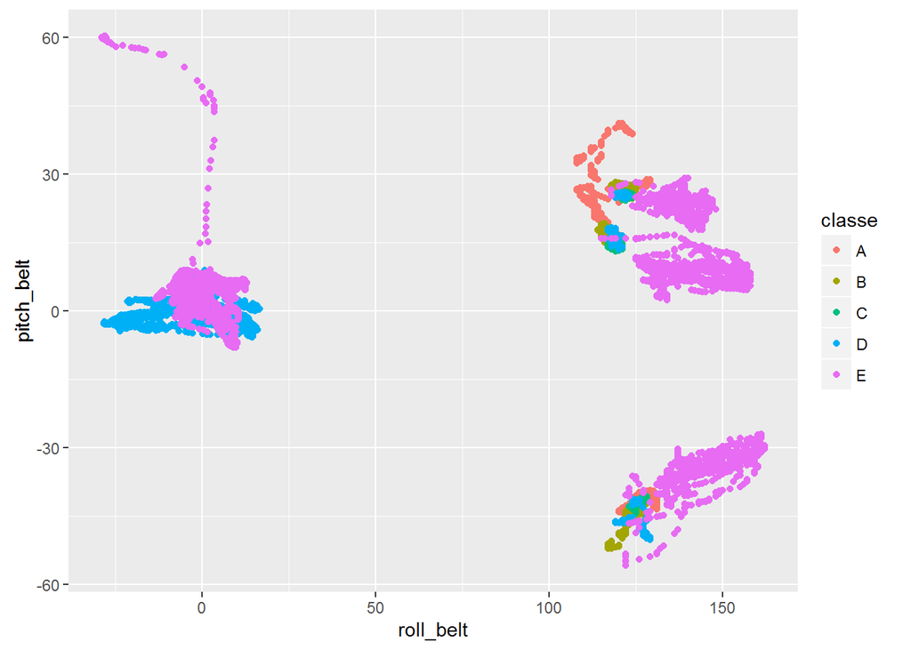

```r
  library(ggplot2)
  qplot(roll_belt, pitch_belt, colour=classe, data=pmlTrain)
```

Examining our plot, class E - throwing hips to the front stands out from the other classes. This seems plausible as this motion could be related to correctly lifting the dumbell and transferring the weight through the spine to the hips.

#### Cross Validation

For cross validation purposes we segregate our processed training set into training and preTest sets using a 60/40 split. This preTest set will later be used to estimate out of sample error and accuracy of the completed model.

```r
  # Further split of training set into trianing and preTest observations
  inTrain <- createDataPartition(y=pmlTrain$classe, p=0.60, list=FALSE)
  training <- pmlTrain[inTrain,]
  preTest <- pmlTrain[-inTrain,]
```

### Model Creaton and Verificaton

From the different machine learining algorithms avaialable, we selected the random forest procedure. We feel this was appropriate as all variables are tested through the classification trees to determine a meaningful predicitive ability of the outcome - the classe variable.

Building random forest classifications for a large number of variables is a computationally intensive task and can take some time. We use the doParallel package in R to enable parallel computations and speed up the process considerably on most personal computers processing limited computations at one time.

```r
  # step 1: configure parallel processing
  library(parallel)
  library(doParallel)
  cluster <- makeCluster(detectCores() -1)
  registerDoParallel(cluster)

  # step 2: configure trainControl object
  fitControl <- trainControl(method = "cv", number = 10, allowParallel = T)

  # step 3: develop training model
  modFit <- train(classe~., method = "rf", data=training, trControl = fitControl)

  # step 4: close the cluster
  stopCluster(cluster)
```

#### Accuracy and Out-of-sample Error

The preTest data split for cross validation is used to initially test the model’s accuracy. The confusion matrix shows predictions against reference classes A-E.

The out of sample error is the error rate observed on the preTest data which is (100% - accuracy = 100% - 99.03% =) 0.97%.

```r
  predictions <- predict(modFit, preTest)
  confusionMatrix(predictions,preTest$classe)
```

```
## Confusion Matrix and Statistics
##
##           Reference
## Prediction    A    B    C    D    E
##          A 2232   16    0    0    0
##          B    0 1497   19    0    0
##          C    0    5 1348   31    1
##          D    0    0    1 1253    1
##          E    0    0    0    2 1440
##
## Overall Statistics
##
##                Accuracy : 0.9903
##                  95% CI : (0.9879, 0.9924)
##     No Information Rate : 0.2845
##     P-Value [Acc > NIR] : < 2.2e-16
##
##                   Kappa : 0.9877
##  Mcnemar's Test P-Value : NA
##
## Statistics by Class:
##
##                      Class: A Class: B Class: C Class: D Class: E
## Sensitivity            1.0000   0.9862   0.9854   0.9743   0.9986
## Specificity            0.9971   0.9970   0.9943   0.9997   0.9997
## Pos Pred Value         0.9929   0.9875   0.9733   0.9984   0.9986
## Neg Pred Value         1.0000   0.9967   0.9969   0.9950   0.9997
## Prevalence             0.2845   0.1935   0.1744   0.1639   0.1838
## Detection Rate         0.2845   0.1908   0.1718   0.1597   0.1835
## Detection Prevalence   0.2865   0.1932   0.1765   0.1600   0.1838
## Balanced Accuracy      0.9986   0.9916   0.9898   0.9870   0.9992
```

### Project Prediction Quiz

Our random forest model is applied to the 20 test cases provided in the final test set. The results are saved to files for project submission.

```r
  predictfinal <- predict(modFit, pmlTest)
  predictfinal
```

```
##  [1] B A B A A E D B A A B C B A E E A B B B
## Levels: A B C D E
```

```r
  results <- "./results"
  if(!file.exists(results)) {dir.create(results)}

  pml_write_files = function(x,y){
    n = length(x)
    for(i in 1:n){
      filename = paste(y,"/problem_id_",i,".txt",sep="")
      write.table(x[i],file=filename,quote=FALSE,row.names=FALSE,col.names=FALSE)
    }
  }

  pml_write_files(predictfinal,results)
```